# Case Study: Preview

# Introduction

Carbon dioxide is one of the main greenhouse gases emitted by human activities. As the concentration of greenhouse gases changed over time because of human activities, the world also has experienced rising global temperatures.

In this case study, we explore the factors that contribute to rising carbon emissions over time. In particular, we will look at 3 factors: GDP per capita, energy use per capita, and the political climate of a country.

# Data

We will use the cleaned data from the R bootcamp.

# Basic data visualization

It is good practice to visualize the data you are working with.

[figure not shown]

```r
data %>% group_by(year) %>%
  summarize(Emissions = sum(emissions, na.rm = T)) %>%
  ggplot(aes(x = year, y = Emissions)) +
  geom_line(size = 1.5) +
  labs(title = "World" ~CO[2]~ "Emissions per year (1751- 2014)",
       y = "Emissions (Metric Tonnes)") +
  theme_classic()
```

[figure not shown]

```r
data %>% group_by(year, country) %>%
  summarize(Emissions = sum(emissions, na.rm = T)) %>%
  ggplot(aes(x = year, y = Emissions, group = country)) +
  geom_line(alpha = 0.4) +
  labs(title = "World" ~CO[2]~ "Emissions per year (1751- 2014)",
       y = "Emissions (Metric Tonnes)") +
  theme_classic()
```

The graph shows that countries who scored lower on the liberal democracy index tend to have higher emissions.

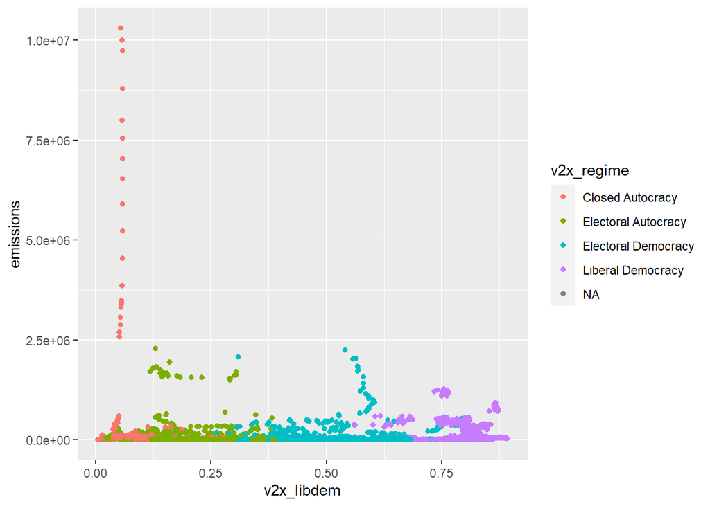

```r
data %>%
  ggplot(aes(x = v2x_libdem, y = emissions, color = v2x_regime)) + geom_point()
```

Some countries with lower GDP per capita have higher emissions. Countries with higher higher GDP per capita have lower emissions. When we added a trend line, we see that there appears to be a positive relationship between GDP per capita and emissions per capita.

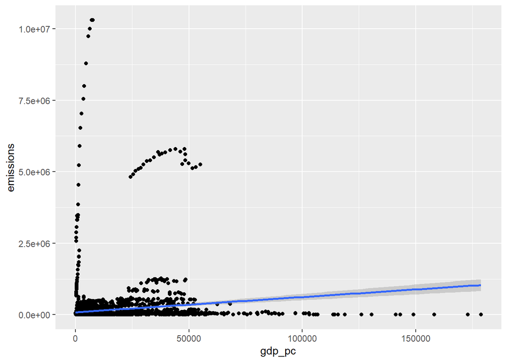

```r
data %>%
  ggplot(aes(x = gdp_pc, y = emissions)) + geom_point() + geom_smooth(method = "lm")
```

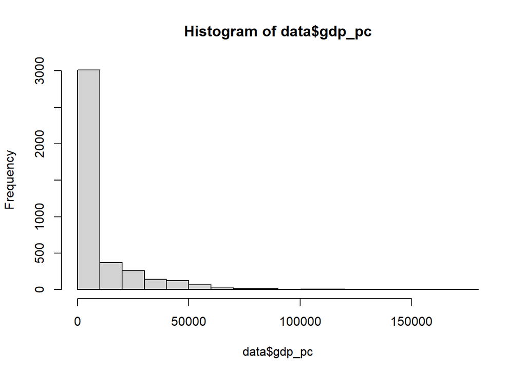

```r
hist(data$gdp_pc)
```

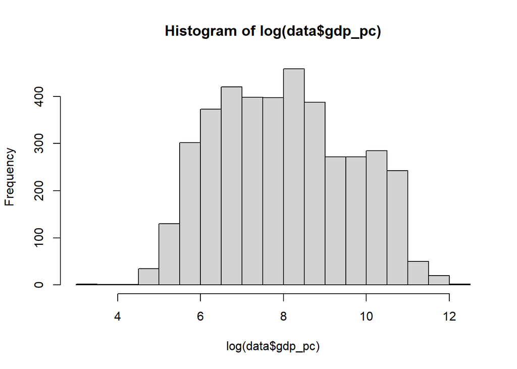

```r
hist(log(data$gdp_pc))
```

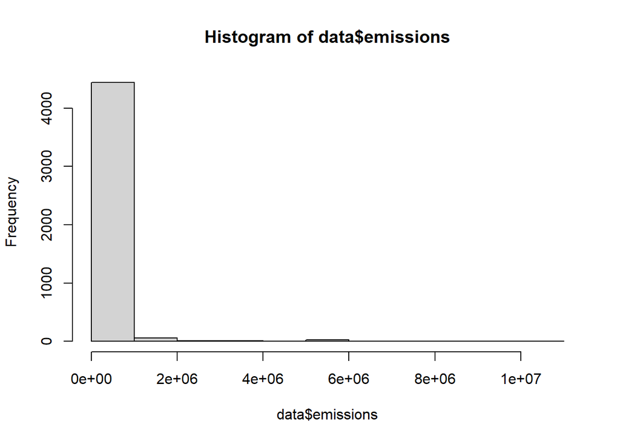

```r
hist(data$emissions)
```

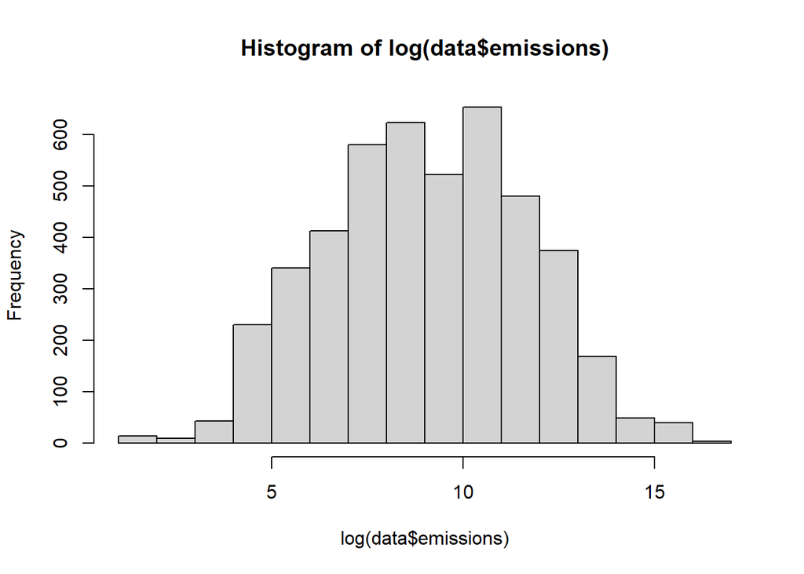

```r
hist(log(data$emissions))
```

# Summary statistics

[output not shown]

# Regressions

$$emissions_i = b_0 + b_1 GDP_i + \varepsilon_i$$
To run an OLS regression, we use the `lm()` function of the `stats` package. The syntax is `lm(y ~ x1 + x2 + x3 + ...)` Printing the object will only give you the coefficients.

```r
reg1 <- lm(emissions ~ gdp_pc, data = data)
reg1
```

```
##
## Call:
## lm(formula = emissions ~ gdp_pc, data = data)
##
## Coefficients:
## (Intercept)       gdp_pc
##    88455.97         5.31
```

To get all the details of the regression, we use the `summary()` function. The output is similar to Stata’s regression output. To extract elements of the regression results, you can use the command `str(summary(reg1))`

```r
summary(reg1)
```

```
##
## Call:
## lm(formula = emissions ~ gdp_pc, data = data)
##
## Residuals:
##      Min       1Q   Median       3Q      Max
## -1038217  -106700   -89634   -73624 10174104
##
## Coefficients:
##              Estimate Std. Error t value Pr(>|t|)
## (Intercept) 8.846e+04  1.173e+04   7.543 5.64e-14 ***
## gdp_pc      5.310e+00  6.251e-01   8.495  < 2e-16 ***
## ---
## Signif. codes:  0 '***' 0.001 '**' 0.01 '*' 0.05 '.' 0.1 ' ' 1
##
## Residual standard error: 640700 on 4018 degrees of freedom
##   (588 observations deleted due to missingness)
## Multiple R-squared:  0.01765,    Adjusted R-squared:  0.0174
## F-statistic: 72.17 on 1 and 4018 DF,  p-value: < 2.2e-16
```

The coefficient $b_1$ tells us that we predict the mean emissions per capita to increase by 5.31 for every dollar increase in GDP per capita. Since its p-value = 0 and is < 0.05, we can reject the null hypothesis that $b_1$ is equal to zero (no effect).

The $r^2$ can be interpreted as as 1.76 percent of the variation in emissions is explained by the variation in GDP per capita.

The Pearson correlation coefficient can be calculated as follows

```r
cor <- cor.test(data$emissions, data$gdp_pc, method = "pearson")
# str(cor)
```

The correlation coefficient of 0.13 with a p-value of 0 that the relationship between emissions per capita and GDP per capita is positive but the relationship is not as strong (not close to 1), although it is statistically significant.

```
sum(residuals(reg1)^2)

mse <- function(reg){
  mean(residuals(reg1)^2)
}

mse(reg1)
```

# Multiple linear regression

Now let’s add more predictors to our model. Based on the literature, there is an inverse U-share relationship between emissions and GDP per capita. In addition, different political climate may affect a country’s level of emissions as well.

The statistical relationship we want to investigate can be defined as:

$$ln emissions_i = b_0 + b_1 ln GDP_i + b_2(lnGDP_i)^2 + b_3PoliticalRegime + \varepsilon_i$$

```r
reg2 <- lm(log(emissions) ~ log(gdp_pc) + I(log(gdp_pc)^2) + v2x_regime, data = data)
summary(reg2)
```

```
##
## Call:
## lm(formula = log(emissions) ~ log(gdp_pc) + I(log(gdp_pc)^2) +
##     v2x_regime, data = data)
##
## Residuals:
##     Min      1Q  Median      3Q     Max
## -5.3357 -1.1387 -0.1105  1.2045  6.5839
##
## Coefficients:
##                               Estimate Std. Error t value Pr(>|t|)
## (Intercept)                   -1.89680    0.81676  -2.322   0.0203 *
## log(gdp_pc)                    2.34404    0.21164  11.076  < 2e-16 ***
## I(log(gdp_pc)^2)              -0.10502    0.01334  -7.874 4.55e-15 ***
## v2x_regimeElectoral Autocracy -0.50887    0.10436  -4.876 1.13e-06 ***
## v2x_regimeElectoral Democracy -0.72599    0.10452  -6.946 4.47e-12 ***
## v2x_regimeLiberal Democracy    0.11324    0.12462   0.909   0.3636
## ---
## Signif. codes:  0 '***' 0.001 '**' 0.01 '*' 0.05 '.' 0.1 ' ' 1
##
## Residual standard error: 1.911 on 3489 degrees of freedom
##   (1113 observations deleted due to missingness)
## Multiple R-squared:  0.3031, Adjusted R-squared:  0.3021
## F-statistic: 303.6 on 5 and 3489 DF,  p-value: < 2.2e-16
```

We see that there are 3 coefficients for the `regime` variable. When you put a categorical variable in a linear regression, you get a different intercept for each level of that variable. In other words, countries in our data are categorized into 4 political regimes, and our model specifies the same slope for how emissions change with GDP per capita, but with different starting point or intercept based on the country’s political regime.

The regime variable is a categorical variable, and like Stata, it will automatically drop one level. We interpret the results in reference to that category.

# References

Wright, Carrie and Ontiveros, Michael and Jager, Leah and Taub, Margaret and Hicks, Stephanie. (2020). https://github.com/opencasestudies/ocs-bp-co2-emissions. Exploring CO2 emissions across time (Version v1.0.0).